# Analyzing usage of Citibikes in New York City for January 2019

This notebook is using data for the usage of citibikes in New York City in January 2019. Pulled from [this](https://www.citibikenyc.com/system-data) website, [here is the data I'm using](https://s3.amazonaws.com/tripdata/JC-201901-citibike-tripdata.csv.zip) to analyze the following:

- How long do people usually ride rental bikes for, and does this have correlation with the distance traveled?
- How is each bike being used?
- What is the main demographic of rental bike users in NYC?

```python
# imports:
import pandas as pd
import os.path
import numpy as np
import matplotlib as mpl
import matplotlib.ticker as ticker
import matplotlib.pyplot as plt
%matplotlib inline
try:
    import geopy.distance
except ImportError:
    print("This notebook requires geopy for distance analysis. Please run pip install geopy: ")

mpl.rcParams['figure.figsize'] = (12,12)
```

## Data Collection

```python
if not os.path.exists("citibike.csv"):
    print("Missing dataset file")
else:
    citibikedata = pd.read_csv("citibike.csv")
```

Show the first few lines:

```python
citibikedata.head(10)
```

|  | tripduration | starttime | stoptime | start station id | start station name | start station latitude | start station longitude | end station id | end station name | end station latitude | end station longitude | bikeid | usertype | birth year | gender |
| --- | --- | --- | --- | --- | --- | --- | --- | --- | --- | --- | --- | --- | --- | --- | --- |
| 0 | 201 | 2019-01-01 03:09:09.7110 | 2019-01-01 03:12:30.8790 | 3183 | Exchange Place | 40.716247 | -74.033459 | 3214 | Essex Light Rail | 40.712774 | -74.036486 | 29612 | Subscriber | 1993 | 1 |
| 1 | 505 | 2019-01-01 05:18:00.1060 | 2019-01-01 05:26:25.9050 | 3183 | Exchange Place | 40.716247 | -74.033459 | 3638 | Washington St | 40.724294 | -74.035483 | 29213 | Subscriber | 1972 | 2 |
| 2 | 756 | 2019-01-01 10:36:33.3400 | 2019-01-01 10:49:10.2600 | 3183 | Exchange Place | 40.716247 | -74.033459 | 3192 | Liberty Light Rail | 40.711242 | -74.055701 | 26164 | Subscriber | 1985 | 1 |
| 3 | 1575 | 2019-01-01 12:43:38.6430 | 2019-01-01 13:09:54.5280 | 3183 | Exchange Place | 40.716247 | -74.033459 | 3638 | Washington St | 40.724294 | -74.035483 | 29672 | Customer | 1969 | 0 |
| 4 | 1566 | 2019-01-01 12:43:39.6010 | 2019-01-01 13:09:46.5100 | 3183 | Exchange Place | 40.716247 | -74.033459 | 3638 | Washington St | 40.724294 | -74.035483 | 29522 | Customer | 1969 | 0 |
| 5 | 737 | 2019-01-01 12:56:53.2040 | 2019-01-01 13:09:11.0400 | 3183 | Exchange Place | 40.716247 | -74.033459 | 3205 | JC Medical Center | 40.716540 | -74.049638 | 29447 | Subscriber | 1993 | 1 |
| 6 | 917 | 2019-01-01 13:03:44.7760 | 2019-01-01 13:19:02.7690 | 3183 | Exchange Place | 40.716247 | -74.033459 | 3277 | Communipaw & Berry Lane | 40.714358 | -74.066611 | 29299 | Subscriber | 1986 | 1 |
| 7 | 3248 | 2019-01-01 13:12:03.1280 | 2019-01-01 14:06:12.0400 | 3183 | Exchange Place | 40.716247 | -74.033459 | 3196 | Riverview Park | 40.744319 | -74.043991 | 29495 | Subscriber | 1992 | 1 |
| 8 | 3168 | 2019-01-01 13:13:12.0450 | 2019-01-01 14:06:00.4110 | 3183 | Exchange Place | 40.716247 | -74.033459 | 3196 | Riverview Park | 40.744319 | -74.043991 | 26312 | Customer | 1969 | 0 |
| 9 | 353 | 2019-01-01 17:07:44.6670 | 2019-01-01 17:13:38.2640 | 3183 | Exchange Place | 40.716247 | -74.033459 | 3202 | Newport PATH | 40.727224 | -74.033759 | 26212 | Subscriber | 1994 | 1 |

According to the website that I pulled the data from, here is the schema defined on this csv file:

> - Trip Duration (seconds)
> - Start Time and Date
> - Stop Time and Date
> - Start Station Name
> - End Station Name
> - Station ID
> - Station Lat/Long
> - Bike ID
> - User Type (Customer = 24-hour pass or 3-day pass user; Subscriber = Annual Member)
> - Gender (Zero=unknown; 1=male; 2=female)
> - Year of Birth

> "This data has been processed to remove trips that are taken by staff as they service and inspect the system, trips that are taken to/from any of our “test” stations (which we were using more in June and July 2013), and any trips that were below 60 seconds in length (potentially false starts or users trying to re-dock a bike to ensure it's secure)."

One interesting thing to note about this is that even if there is a not null value for the "Gender" column, any value with 0 is "unknown," which may make it harder to give us a real insight without filtering all 0 values out.

## Data Preperation

Below we can see metadata about this dataset:

```python
citibikedata.info()
```

```
<class 'pandas.core.frame.DataFrame'>
RangeIndex: 19676 entries, 0 to 19675
Data columns (total 15 columns):
tripduration               19676 non-null int64
starttime                  19676 non-null object
stoptime                   19676 non-null object
start station id           19676 non-null int64
start station name         19676 non-null object
start station latitude     19676 non-null float64
start station longitude    19676 non-null float64
end station id             19676 non-null int64
end station name           19676 non-null object
end station latitude       19676 non-null float64
end station longitude      19676 non-null float64
bikeid                     19676 non-null int64
usertype                   19676 non-null object
birth year                 19676 non-null int64
gender                     19676 non-null int64
dtypes: float64(4), int64(6), object(5)
memory usage: 2.3+ MB
```

### Null values

The most important thing to first look at is the number of null values so we can deal with them accordingly. Here are the number of null values in this dataset.

```python
citibikedata.isnull().sum()
```

```
tripduration               0
starttime                  0
stoptime                   0
start station id           0
start station name         0
start station latitude     0
start station longitude    0
end station id             0
end station name           0
end station latitude       0
end station longitude      0
bikeid                     0
usertype                   0
birth year                 0
gender                     0
dtype: int64
```

While this is good that there are no null values in this, as I said before, the "Gender" field has 0 for values that aren't actually useful to us. I want to know if there are enough non-zero values in "Gender" for me to be able to meaningfully use it

```python
citibikedata.gender.value_counts()
```

```
1    14929
2     4171
0      576
Name: gender, dtype: int64
```

Since there is an overwhelmingly larger number of non-zero values compared to zero values, we don't have to worry about inconsistent data for the "Gender" field.

Next, I want to convert the start time and end time to a datetime object.

### Data/time data

```python
citibikedata["starttime"].head()
```

```
0    2019-01-01 03:09:09.7110
1    2019-01-01 05:18:00.1060
2    2019-01-01 10:36:33.3400
3    2019-01-01 12:43:38.6430
4    2019-01-01 12:43:39.6010
Name: starttime, dtype: object
```

As you can see, these strings are stored as objects, when I want them as datetime strings.

```python
citibikedata["starttime"] = pd.to_datetime(citibikedata["starttime"], format='%Y-%m-%d %H:%M:%S.%f')
citibikedata["stoptime"] = pd.to_datetime(citibikedata["stoptime"], format='%Y-%m-%d %H:%M:%S.%f')
citibikedata["starttime"].head()
```

```
0   2019-01-01 03:09:09.711
1   2019-01-01 05:18:00.106
2   2019-01-01 10:36:33.340
3   2019-01-01 12:43:38.643
4   2019-01-01 12:43:39.601
Name: starttime, dtype: datetime64[ns]
```

```python
citibikedata["stoptime"].head()
```

```
0   2019-01-01 03:12:30.879
1   2019-01-01 05:26:25.905
2   2019-01-01 10:49:10.260
3   2019-01-01 13:09:54.528
4   2019-01-01 13:09:46.510
Name: stoptime, dtype: datetime64[ns]
```

#### Trip time accuracy

One thing that I was curious about is what the tripduration field represented. The citibike website did not make it clear what this field meant. We're the bikes smart enough to track how long the bikes were actually used? Did it not count the time the bike was stationary? Or is it just the total length the bike was rented out for? To figure this out, I did my own calculation. I did this by generating a timedelta object from the difference in start and stop times, then converting them to minues.

```python
trip_seconds = []
trip_time = []

for index in range(len(citibikedata)):
    elapsed_time = citibikedata["stoptime"].iat[index] - citibikedata["starttime"].iat[index]
    elapsed_seconds = elapsed_time.total_seconds()
    elapsed_minutes = elapsed_seconds / 60
    trip_seconds.append(elapsed_seconds)
    trip_time.append(elapsed_minutes)

#I'm actually adding these calculated values to the dataframe because it's nicer to work with minutes
citibikedata = citibikedata.assign(trip_time=trip_time)
```

Now we can compare my calculated field (which just represents how long the bike was rented out for) and the `tripdata` field

```python
trip_seconds[:10]
```

```
[201.168,
 505.799,
 756.92,
 1575.885,
 1566.909,
 737.836,
 917.993,
 3248.912,
 3168.366,
 353.597]
```

```python
citibikedata["tripduration"].head(10)
```

```
0     201
1     505
2     756
3    1575
4    1566
5     737
6     917
7    3248
8    3168
9     353
Name: tripduration, dtype: int64
```

Obviously, since our data lines up, the tripduration field in the citibike data only tracks how long the bike was rented, and isn't indicative of how long the bike was actually used.

## Analyzing the data

### Geolocation data

Since I want to determine average trip distances, I am going to calculate it and append it to the dataset. To do this, I'm going to calculate the distance traveled from the start to the finish using the python GeoPy package. I didn't just use a simple distance formula, since the earth is curved and calculating distances accurately involves some more complex computation that GeoPy takes care of for me. While I belive this is negligible at city scale, I decided to still use it to make sure it's as accurate as posible.

```python
distance_traveled = []

for row in range(len(citibikedata)):
    coord1 = (citibikedata["start station latitude"].iat[row], citibikedata["start station longitude"].iat[row])
    coord2 = (citibikedata["end station latitude"].iat[row], citibikedata["end station longitude"].iat[row])
    distance_traveled.append(geopy.distance.distance(coord1, coord2).km)
```

```python
citibikedata = citibikedata.assign(distance_traveled=distance_traveled)
citibikedata.head()
```

|  | tripduration | starttime | stoptime | start station id | start station name | start station latitude | start station longitude | end station id | end station name | end station latitude | end station longitude | bikeid | usertype | birth year | gender | trip_time | distance_traveled |
| --- | --- | --- | --- | --- | --- | --- | --- | --- | --- | --- | --- | --- | --- | --- | --- | --- | --- |
| 0 | 201 | 2019-01-01 03:09:09.711 | 2019-01-01 03:12:30.879 | 3183 | Exchange Place | 40.716247 | -74.033459 | 3214 | Essex Light Rail | 40.712774 | -74.036486 | 29612 | Subscriber | 1993 | 1 | 3.352800 | 0.462744 |
| 1 | 505 | 2019-01-01 05:18:00.106 | 2019-01-01 05:26:25.905 | 3183 | Exchange Place | 40.716247 | -74.033459 | 3638 | Washington St | 40.724294 | -74.035483 | 29213 | Subscriber | 1972 | 2 | 8.429983 | 0.909841 |
| 2 | 756 | 2019-01-01 10:36:33.340 | 2019-01-01 10:49:10.260 | 3183 | Exchange Place | 40.716247 | -74.033459 | 3192 | Liberty Light Rail | 40.711242 | -74.055701 | 26164 | Subscriber | 1985 | 1 | 12.615333 | 1.959896 |
| 3 | 1575 | 2019-01-01 12:43:38.643 | 2019-01-01 13:09:54.528 | 3183 | Exchange Place | 40.716247 | -74.033459 | 3638 | Washington St | 40.724294 | -74.035483 | 29672 | Customer | 1969 | 0 | 26.264750 | 0.909841 |
| 4 | 1566 | 2019-01-01 12:43:39.601 | 2019-01-01 13:09:46.510 | 3183 | Exchange Place | 40.716247 | -74.033459 | 3638 | Washington St | 40.724294 | -74.035483 | 29522 | Customer | 1969 | 0 | 26.115150 | 0.909841 |

### Observations based on distance traveled

Now that I've augmented the dataset with the distance traveled, we can make some interesting observations. First of all, just by looking at the data, we can find some values of `distance_traveled` with the value `0.0`. For example, value number 14:

```python
citibikedata["distance_traveled"].iloc[14]
```

```
0.0
```

As you can see, the `distance_traveled` field is 0. Are these error fields? Well we can look at the checkout time and the checkin time to see if there was an actual bike rented, or if it's an erronous value.

```python
citibikedata["starttime"].iloc[14]
```

```
Timestamp('2019-01-01 21:52:09.298000')
```

```python
citibikedata["stoptime"].iloc[14]
```

```
Timestamp('2019-01-01 21:54:00.455000')
```

As we can see, the times are different (52:09 vs 54:00). This indicates that the bike was checked out, but hasn't traveled any distance to the end station. i.e. the bike was returned to the same station that we started at. We can now see how many bikes were displaced from their original station at the end of the ride by counting all non-zero values.

```python
displaced = 0
not_displaced = 0

for index in range(len(citibikedata)):
    if (citibikedata["distance_traveled"].iat[index]):
        displaced+=1
    else:
        not_displaced+=1

print("%d bikes were displaced, and %d were not" % (displaced,not_displaced))
```

```
19254 bikes were displaced, and 422 were not
```

So we can see that the majority of bikes were actually displaced (traveled from one station to another). Assuming that displacement distance is a rough indicator of how far the bikes have traveled, we can deduce some values. First of all, lets look at the furthest distance a bike has traveled.

```python
citibikedata["distance_traveled"].max()
```

```
4.356450380921922
```

4.3km is a lot of cycling. Again, this is the displacement of the bike from one station to another, so the cyclist could have cycled more than that, but we know the longest trip was at least 4.3km. Lets also look at the average distance a bike has traveled:

```python
citibikedata["distance_traveled"].mean()
```

```
0.9250056120757401
```

The average distance a bike displaces just under 1km, so it's safe to assume that on average rented citibike rides are about 1km long.

### Bike rental time vs bike travel distance

We can also figure out if there is a correlation between how long a bike has been rented, and how far the bike has traveled.

#### Total trip time vs distance traveled by citibikes

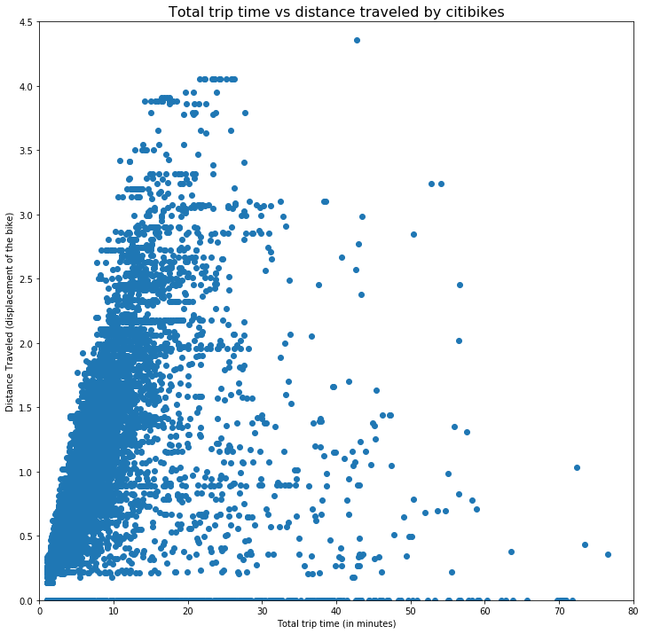

```python
plt.figure()
plt.scatter(citibikedata["trip_time"],citibikedata["distance_traveled"])
plt.axis([0,80,0,4.5])
plt.ylabel("Distance Traveled (displacement of the bike)")
plt.xlabel("Total trip time (in minutes)")
plt.title("Total trip time vs distance traveled by citibikes", {'fontsize':16})
```

We can see some correlation. As the trip time incrases, generally do does the distance traveled. However, there are plenty of data points where bikes were rented for close to 80 minutes, but traveled (displaced) very little. I assume these data points are either people not riding their bikes the whole time they are rented, or people who rode it for some distance, then returned it to the same station they originally found the bike.

## Data for each bike

I now want to look at the usage of each bike. This is doable by creating a new dataframe that is grouped by the "bikeid" field.

```python
perbikedata = citibikedata.groupby("bikeid")
perbikedata.sum().head()
```

| bikeid | tripduration | start station id | start station latitude | start station longitude | end station id | end station latitude | end station longitude | birth year | gender | trip_time | distance_traveled |
| --- | --- | --- | --- | --- | --- | --- | --- | --- | --- | --- | --- |
| 17432 | 1766 | 19398 | 244.290626 | -444.223660 | 19306 | 244.288518 | -444.218205 | 11909 | 6 | 29.505533 | 3.946271 |
| 26151 | 3886 | 32613 | 407.302673 | -740.550833 | 32604 | 407.291516 | -740.530167 | 19852 | 14 | 64.848400 | 9.736278 |
| 26152 | 3041 | 30019 | 366.504321 | -666.570227 | 29728 | 366.496056 | -666.577422 | 17870 | 14 | 50.775850 | 6.887986 |
| 26153 | 18356 | 221164 | 2769.015661 | -5034.907717 | 220816 | 2768.987185 | -5034.904064 | 134775 | 81 | 306.447300 | 50.570153 |
| 26155 | 15149 | 127544 | 1588.064984 | -2887.798568 | 126787 | 1588.050622 | -2887.791664 | 77243 | 42 | 252.812183 | 35.374432 |

Lets see which bikes were being rented out the longest this January. (this dataset is the whole month of January) The result is in hours.

```python
trip_per_bike = perbikedata.sum().sort_values(by=["trip_time"], ascending=False)
trip_per_bike = trip_per_bike / 60 #this conversion brings the result to hours
trip_per_bike["trip_time"].head(20)
```

```
bikeid
29499    57.574434
29206    52.624199
26202    27.653190
29678    22.506366
29508    20.737233
26280    18.290184
26227    17.636903
29259    17.061096
26300    16.321090
26161    15.168531
29485    14.475388
29636    12.743166
29598    12.644808
26164    12.404492
29127    11.664298
26206    11.581995
29225    11.378082
26232    11.332203
26216    11.087149
29520    11.029803
Name: trip_time, dtype: float64
```

The top bike, 29499, was rented for more than 57 hours! Lets take a look at all the trips that this bike has been on:

```python
longest_bike = citibikedata[citibikedata["bikeid"]==29499]
longest_bike.head()
```

|  | tripduration | starttime | stoptime | start station id | start station name | start station latitude | start station longitude | end station id | end station name | end station latitude | end station longitude | bikeid | usertype | birth year | gender | trip_time | distance_traveled |
| --- | --- | --- | --- | --- | --- | --- | --- | --- | --- | --- | --- | --- | --- | --- | --- | --- | --- |
| 378 | 397 | 2019-01-14 19:06:30.966 | 2019-01-14 19:13:08.904 | 3183 | Exchange Place | 40.716247 | -74.033459 | 3214 | Essex Light Rail | 40.712774 | -74.036486 | 29499 | Subscriber | 1993 | 1 | 6.632300 | 0.462744 |
| 395 | 663 | 2019-01-15 17:32:58.127 | 2019-01-15 17:44:02.099 | 3183 | Exchange Place | 40.716247 | -74.033459 | 3278 | Monmouth and 6th | 40.725685 | -74.048790 | 29499 | Subscriber | 1969 | 0 | 11.066200 | 1.666289 |
| 545 | 326 | 2019-01-21 09:31:21.374 | 2019-01-21 09:36:47.983 | 3183 | Exchange Place | 40.716247 | -74.033459 | 3202 | Newport PATH | 40.727224 | -74.033759 | 29499 | Subscriber | 1991 | 1 | 5.443483 | 1.219199 |
| 2162 | 210 | 2019-01-07 07:18:46.458 | 2019-01-07 07:22:16.719 | 3186 | Grove St PATH | 40.719586 | -74.043117 | 3205 | JC Medical Center | 40.716540 | -74.049638 | 29499 | Subscriber | 1976 | 2 | 3.504350 | 0.646502 |
| 2228 | 552 | 2019-01-07 18:22:34.522 | 2019-01-07 18:31:47.380 | 3186 | Grove St PATH | 40.719586 | -74.043117 | 3214 | Essex Light Rail | 40.712774 | -74.036486 | 29499 | Subscriber | 1974 | 1 | 9.214300 | 0.941389 |

Lets see how many times has this bike actually been rented out?

```python
len(longest_bike)
```

```
54
```

So while 57 hours seems like a long time, it's because each trip actually was only rented out for about an hour. I'm going to verify this.

```python
longest_bike["trip_time"].mean()
```

```
63.97159290123457
```

The average trip was about an hour for this particular bike. We can actually see if this trend (more total minutes rented = more trips, not longer trips) holds up for the entire dataset.

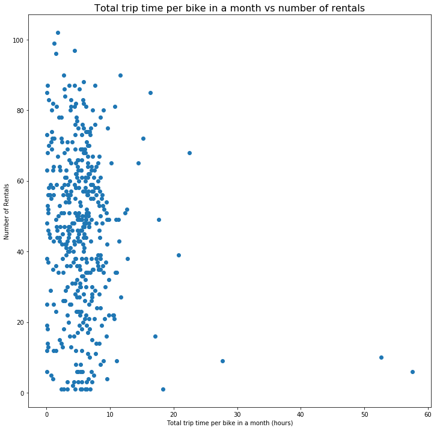

```python
plt.figure()
plt.scatter(trip_per_bike["trip_time"],perbikedata.size())
plt.xlabel("Total trip time per bike in a month (hours)")
plt.ylabel("Number of Rentals")
plt.title("Total trip time per bike in a month vs number of rentals", {'fontsize':16})
```

Lets filter out any value over 12 to see where most values lie.

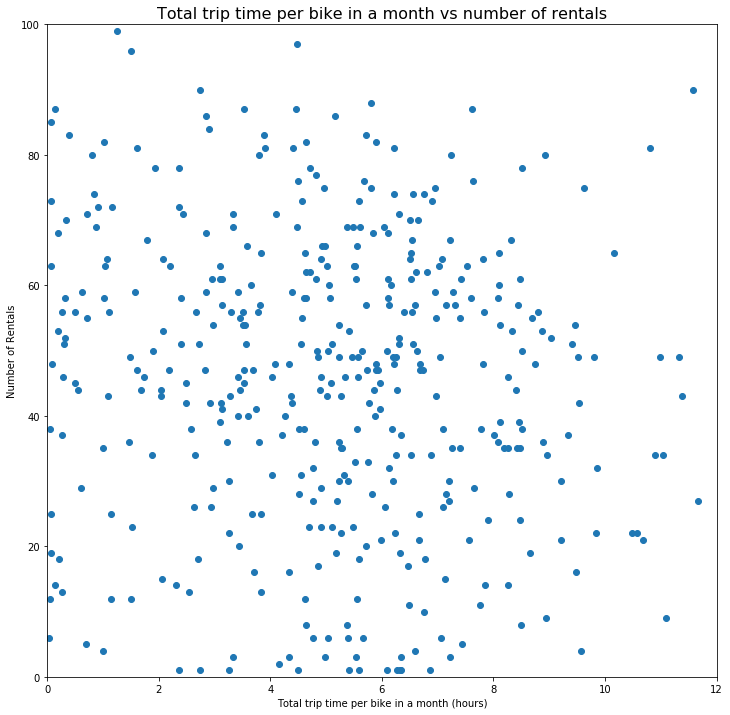

```python
plt.figure()
plt.scatter(trip_per_bike["trip_time"],perbikedata.size())
plt.axis([0,12,0,100])
plt.xlabel("Total trip time per bike in a month (hours)")
plt.ylabel("Number of Rentals")
plt.title("Total trip time per bike in a month vs number of rentals", {'fontsize':16})
```

## Demographic of users

Let's take a look at how many users of each gender use citibike: (0 is unknown, 1 is men and 2 is women)

```python
citibikedata.groupby("gender").size()
```

```
gender
0      576
1    14929
2     4171
dtype: int64
```

As we can see, men overwhelmingly use citibike more than women. Now lets take a look at the age distribution. First, I want to transform the data by calculating the actual age, since birth year is a relatively useless data point. I binned the ages, since I wasn't interested to know the exact ages, but it would be easier to make inferences off of binned data:

```python
binned_ages = []

for index in range(len(citibikedata)):
    if (2019-citibikedata["birth year"].iat[index] < 11):
        binned_ages.append("0-10")
    elif (2019-citibikedata["birth year"].iat[index] < 21):
        binned_ages.append("10-20")
    elif (2019-citibikedata["birth year"].iat[index] < 31):
        binned_ages.append("20-30")
    elif (2019-citibikedata["birth year"].iat[index] < 41):
        binned_ages.append("30-40")
    elif (2019-citibikedata["birth year"].iat[index] < 51):
        binned_ages.append("40-50")
    elif (2019-citibikedata["birth year"].iat[index] < 61):
        binned_ages.append("60-70")
    else:
        binned_ages.append("70+")

citibikedata = citibikedata.assign(age=binned_ages)
```

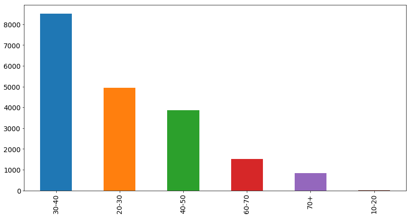

```python
citibikedata["age"].value_counts().plot(kind='bar',figsize=(14,7),fontsize=14)
```

While I wasn't surprised that older people tend to use the bikes less, and teenagers and children didn't use citibike (less incentive to spend money on rental service), I was surprised that there were more 30-40 year olds than there were 20-30 year olds. I would have guessed that young professionals rented more bikes, but it seems that the service is the most popular among 30-40 year olds.

## Further analysis

Here are some things that could be looked into more

- Calculate carbon footprint offset per bike ride, to determine the impact of citibike on the environment
- Use geographical data to determine where in New York the citibikes are used the most
- More comprehensive analysis on demographics: why do certain age groups rent citibikes? What jobs do these people have? What income levels are represented?